# Reproducible Research Project 1

Melissa M. Sovak, Ph.D.

October 15, 2015

## Loading and preprocessing the data

```r
setwd("/Users/lt_sovak/Dropbox/Coursera/Data Science Specialization/DS Course 5")

activityData<-read.csv("./Project 1/activity.csv", header=TRUE, colClasses=c("numeric", "character", "numeric"), stringsAsFactors=FALSE)

attach(activityData)
```

## What is the mean total number of steps taken per day?

1. Calculate the total number of steps taken per day

```r
stepsByDay<-aggregate(steps~date, FUN=sum, na.rm=TRUE)
stepsByDay
```

```
##        date steps
## 1  10/10/12  9900
## 2  10/11/12 10304
## 3  10/12/12 17382
## 4  10/13/12 12426
## 5  10/14/12 15098
## 6  10/15/12 10139
## 7  10/16/12 15084
## 8  10/17/12 13452
## 9  10/18/12 10056
## 10 10/19/12 11829
## 11  10/2/12   126
## 12 10/20/12 10395
## 13 10/21/12  8821
## 14 10/22/12 13460
```

[output cut: 39 more lines]

2. Make a histogram of the total number of steps taken each day

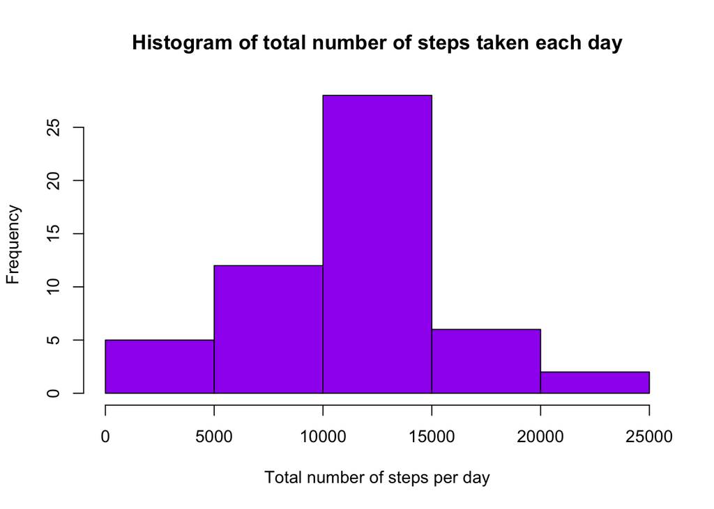

```r
hist(stepsByDay$steps, xlab="Total number of steps per day", main="Histogram of total number of steps taken each day", col="purple")
```

3. Calculate and report the mean and median of the total number of steps taken per day

```r
mean(stepsByDay$steps)
```

```
## [1] 10766.19
```

```r
median(stepsByDay$steps)
```

```
## [1] 10765
```

The mean total number of steps is 10766.19 and the median is 10765.

## What is the average daily activity pattern?

### Make a time series plot (i.e. type = “l”) of the 5-minute interval (x-axis) and the average number of steps taken, averaged across all days (y-axis)

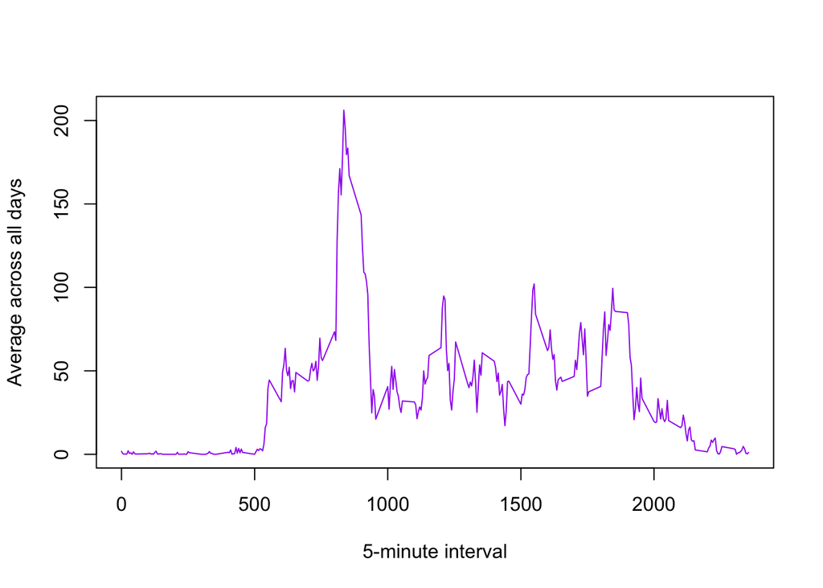

```r
avgTime<-tapply(steps, interval, mean, na.rm=TRUE)

plot(row.names(avgTime), avgTime, type="l", xlab="5-minute interval", ylab="Average across all days", man="Average nmber of steps taken", col="purple")
```

There appears to be a peak around interval 800.

### Which 5-minute interval, on average across all the days in the dataset, contains the maximum number of steps?

```r
maxInt<-which.max(avgTime)

names(maxInt)
```

```
## [1] "835"
```

The interal is 835.

## Impute the missing values

1. Calculate and report the total number of missing values in the dataset

```r
numOfNAS<-sum(is.na(steps))
numOfNAS
```

```
## [1] 2304
```

There are 2304 missing values.

### Devise a strategy for filling in all of the missing values in the dataset. The strategy does not need to be sophisticated. For example, you could use the mean/median for that day, or the mean for that 5-minute interval, etc.

```r
#Find NAS and replace with mean of steps
naLocation<-which(is.na(steps))
meanVec<-rep(mean(steps, na.rm=TRUE), times=length(naLocation))
```

We use the mean to impute in the missing values.

### Create a new dataset that is equal to the original dataset but with the missing data filled in

```r
activityData[naLocation, "steps"]<-meanVec
```

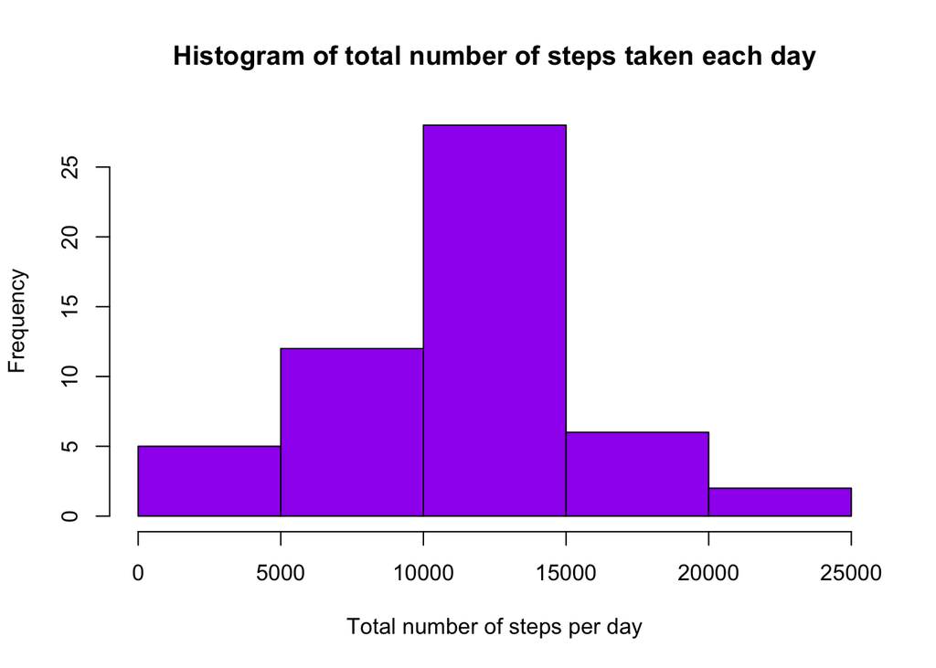

```r
newStepsByDay<-aggregate(steps~date, FUN=sum)

hist(stepsByDay$steps, xlab="Total number of steps per day", main="Histogram of total number of steps taken each day", col="purple")
```

```r
mean(stepsByDay$steps)
```

```
## [1] 10766.19
```

```r
median(stepsByDay$steps)
```

```
## [1] 10765
```

## Are there differences in activity patterns between weekdays and weekends?

1. Create a new factor variable in the dataset with two levels – “weekday” and “weekend” indicating whether a given date is a weekday or weekend day.

```r
date<-as.POSIXct(date, format="%m/%d/%y")
dayOfWeek<-weekdays(date)

dayType<-NULL
for(i in 1:nrow(activityData)) {

  if(dayOfWeek[i]=="Saturday") {
    dayType[i]<-"Weekend"
  }
  else if(dayOfWeek[i]=="Sunday") {
    dayType[i]<-"Weekend"
  }
  else {
    dayType[i]<-"Weekday"
  }
}
activityData$dayOfWeek<-dayOfWeek

activityData$dayType<-dayType
```

2. Make a panel plot containing a time series plot (i.e. type = “l”) of the 5-minute interval (x-axis) and the average number of steps taken, averaged across all weekday days or weekend days (y-axis). See the README file in the GitHub repository to see an example of what this plot should look like using simulated data.

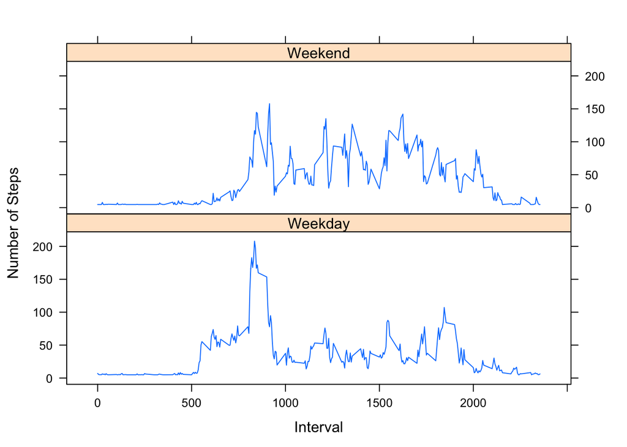

```r
stepsByDayAndType<-aggregate(steps~interval+dayType, data=activityData, mean)
library(lattice)

xyplot(steps~interval|dayType, stepsByDayAndType,  type="l", xlab="Interval", ylab="Number of Steps", layout=c(1,2))
```

Weekends appear to have more peaks than weekdays.